# Kapitel 23 Vetenskaplig metod

## 23.1 Inledning

- Population
- Medelvärde
- Spridningsmått
- Konfidensintervall
- Prediktionsintervall

## 23.2 Population

Figuren nedan visar ett fiktivt exempel på hur två olika studier representerar ett urval från hela populationen (grå färg). Medelvärde och spridning (konfidensintervall) är markerade med en punkt och en linje.

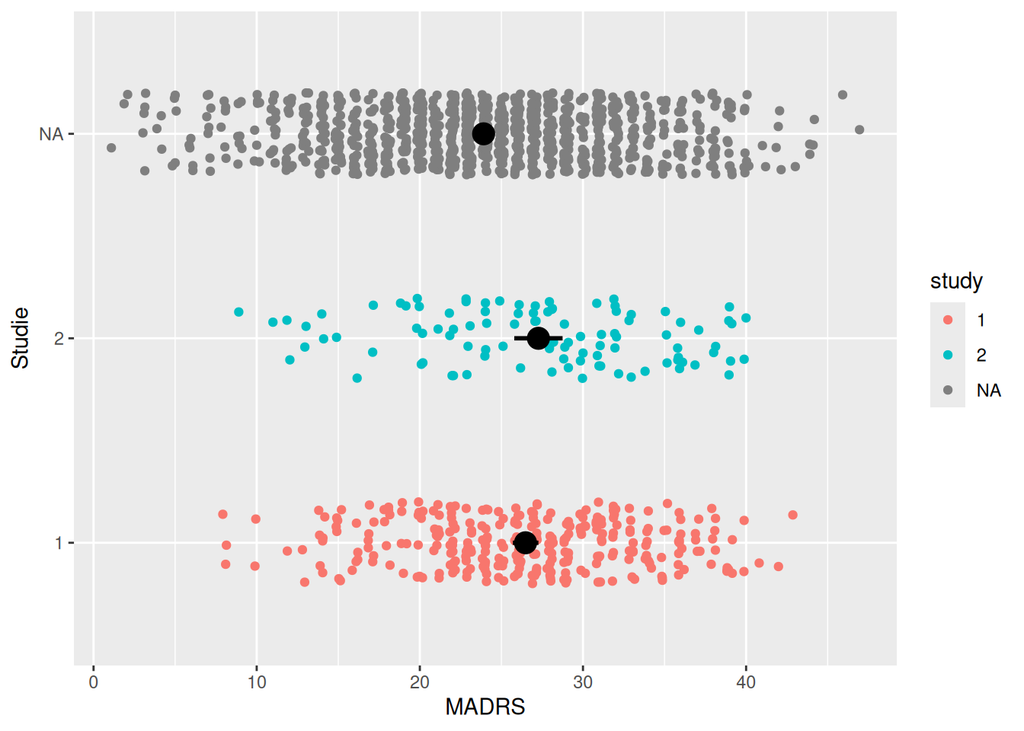

Referens MADRS distribution se [282].

## 23.3 Beräkning av varians och precision

- Residual = observerat värde - medelvärde
- Varians (S^2) = summa(residualer^2) / n-1
- Standardavvikelse (SD) = sqrt(varians)
- Standard Error (SE) = SD/sqrt(n)
- Konfidensintervall = Medelvärde +/- 1.96*SE

## 23.4 Effekt

1. Sann effekt $\theta$, eller i en viss studie $\theta_\kappa$
2. Observerad effekt $\hat{\theta}_\kappa$

a och b skiljer sig pga att urvalet representerar ej hela populationen och därför ger upphov till sampling error $\epsilon_\kappa$

$\epsilon_\kappa$ kan kvantifieras av Standard Error (SE), vilket bygger på ett antagande om fördelning (oftast normalfördelning)

$$\begin{equation}
SE = \frac{s}{\sqrt{n}}
\end{equation}$$

s är standardavvikelsen

## 23.5 Medelvärde mm

Det aritmetiska medelvärdet $\bar{x}$ beräknas genom att summera alla individuella värden $x_i$ i urvalet och sedan dividera summan med urvalets storlek (n).

$$\begin{equation}
\bar{x} = \frac{\sum^{n}_{i=1}x_i}{n}
\end{equation}$$

Standard error of a proportion:

$$\begin{equation}
SE_{p} = \sqrt{\frac{p(1-p)}{n}}
\end{equation}$$

Proportioner transformeras ofta med logit innan de slås samman (annars skevhet om p nära 0 eller 1). För detta används odds.

## 23.6 RR och OR

| Exposed | Outcome | Not Outcome | Risk | Odds |
| --- | --- | --- | --- | --- |
| Yes | A | B | A/(A+B) | A/B |
| No | C | D | C/(C+D) | C/D |
| Ratio |  |  | (A/(A+B))/C/(C+D) | (A/B)/(C/D) |

Risk: Cumulative incidence (average risk). Om utfallet är ovanligt är odds~risk.

## 23.7 Prediktionsintervall och konfidensintervall

Exempel: Låt säga att kroppslängden hos alla vuxna i världen är i medeltal 171 cm. I en studie av kroppslängd kommer ett urval av dessa att finnas med och medelvärdet kan då bli tex 168 cm. Det 95%-iga konfidensintervallet i studien kan vara tex 160-175 cm (hur snävt det blir beror på studiens N). Siffran 95% innebär att om studien görs om flera gånger kommer 95% av studiernas CI att innehålla det sanna medelvärdet (171 cm).

Konfidensintervallet representerar precisionen för det beräknade medelvärdet. Man kan säga att CI är det intervall där poulationens sanna medelvärde sannolikt ligger.

Prediktionsintervall (PI) är en uppskattning av det intervall inom vilket en enda framtida observation (med en viss sannolikhet) kommer att falla, givet vad som redan observerats. Det uttalar sig alltså inte om medelvärdet.

Exempel: Om man mäter ett antal kast med en 6-sidig tärning kommer konfidensintervallet att krympa närmare medelvärdet 3.5 ju fler observationer som görs. Prediktionsintervallet däremot kommer att vara ca 1-6 oavsett hur många mätningar som gjorts.

I metaanlyser anges vanligen I2 och T2 som mått på heterogenitet. I2 är beroende av sample size (K), vilket kan ge låga (icke signifikanta) värden när det är få studier och tvärtom. T2 är svårtolkat eftersom det är ett värde upphöjt i två och därför inte korresponderar till effektmåttet[283].

I metaanalyser är prediktionintervallet användbart eftersom det fångar heterogenitet mellan studier på samma skala som utfallet har mätts med[283] (i motsats till andra vanliga mått på heterogenitet).

I en metaanlys representerar PI variabiliteten i effekten över olika “settings” (studier med tex olika inklusionskriterier). När det är låg heterogenitet mellan studier närmar sig PI konfidensintervallet. Vid hög heterogenitet blir PI vidare än CI.

I en metaanalys är PI det intervall inom vilket medelvärdet i en ny studie förväntas falla om den studien valdes slumpmässigt från den population av studier som ingår i metaanalysen. Det kan också tolkas som en sammanfattning av spridningen av undeliggande effekter i de inkluderade studierna.

Problem med PI i metaanalyser är att det bygger på ett antagande om att effekterna i de olika studierna är normalfördelade, vilket ifall antalet studier är litet kan ge felaktigt snnävt eller stort PI. Cochrane rekommenderar att PI presenteras om det är >10 studier och en funnel plot inte visar någon tydlig assymetri.

Probabilistiskt svar på AD: https://www.ncbi.nlm.nih.gov/pmc/articles/PMC8134509/

## 23.8 Resurser

[Cohcrane](https://www.cochranelibrary.com/search)

[Cochrane handbook](https://training.cochrane.org/handbook/current/chapter-10)

[Metaanalyser i R](https://bookdown.org/MathiasHarrer/Doing_Meta_Analysis_in_R/effects.html)